# 70-467 Machine Learning for Business Analytics

## Where on the curve should Citrus Hill be?

Hypothetical costs. Each line on the right is $\text{Cost}(k) = c_{FP} \cdot FP(k) + c_{FN} \cdot FN(k)$ at threshold $k$.

$c_{FP}$: cost of a wasted coupon. $FP(k)$: MM buyers predicted CH. $c_{FN}$: cost of a missed CH buyer. $FN(k)$: CH buyers predicted MM.

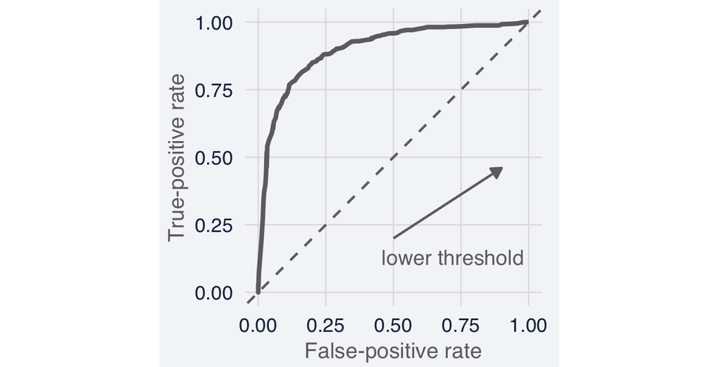

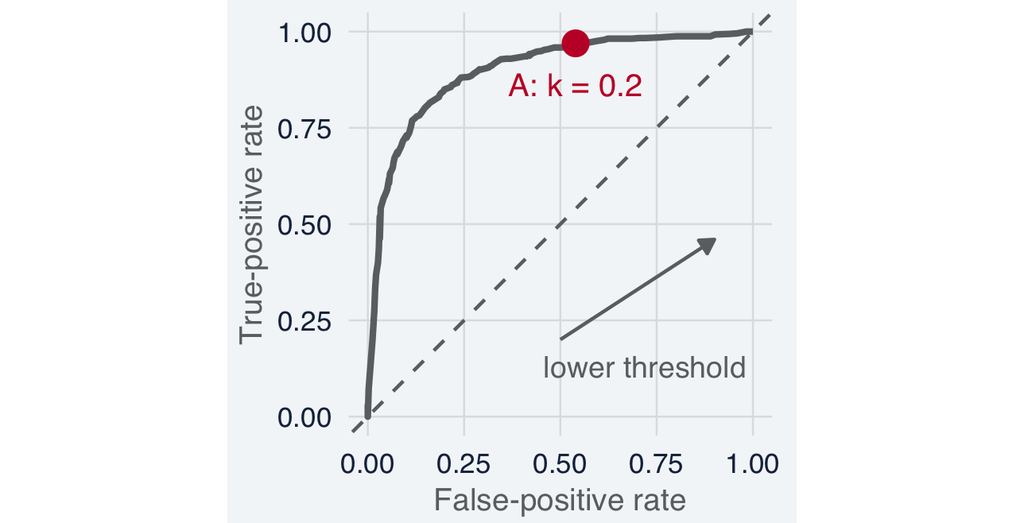

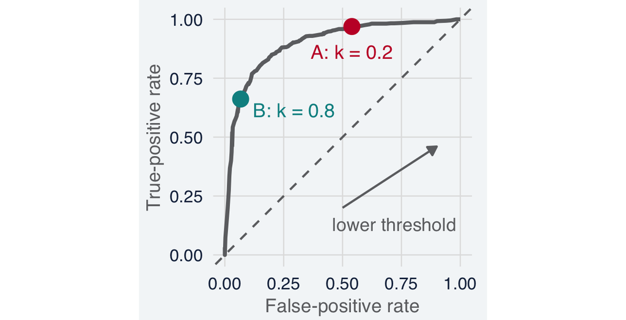

[figure not shown]

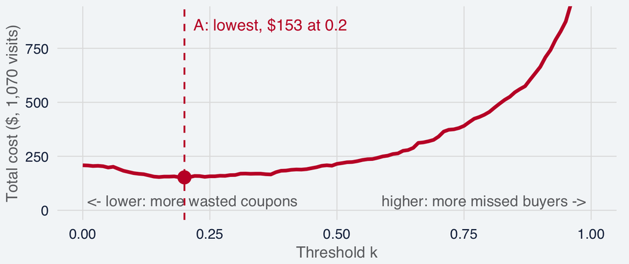

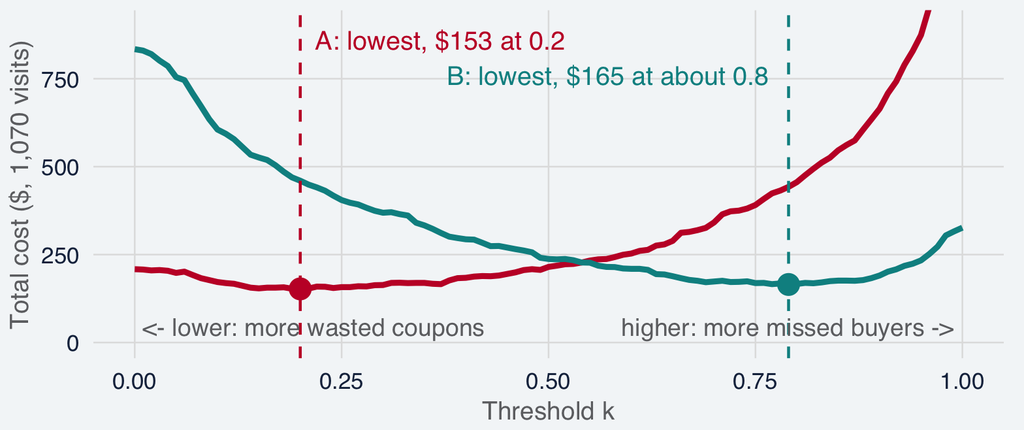

A: a missed CH buyer costs more

Coupon $c_{FP} = \$0.50$, missed buyer $c_{FN} = \$2$. Best at **0.2**: 97% of CH buyers found, 225 coupons wasted.

Red dot: high on the curve. Red line: lowest cost, $153.

B: a wasted coupon costs more

Coupon $c_{FP} = \$2$, missed buyer $c_{FN} = \$0.50$. Best at **about 0.8**: 28 coupons wasted, a third of CH buyers missed.

Teal dot: low on the curve. Teal line: lowest cost, $165.

Lowest cost at $k^* = \dfrac{c_{FP}}{c_{FP} + c_{FN}}$: $\color{#C41230}{\dfrac{0.5}{0.5 + 2} = 0.2}$ and $\color{#008F91}{\dfrac{2}{2 + 0.5} = 0.8}$, the two dashed lines.

## Which model gives the better curve?

On the ROC graph we wer trying to choose a point on one curve. However, before that, which model gives the better curve? Compare our model with a model that uses PriceDiff only.

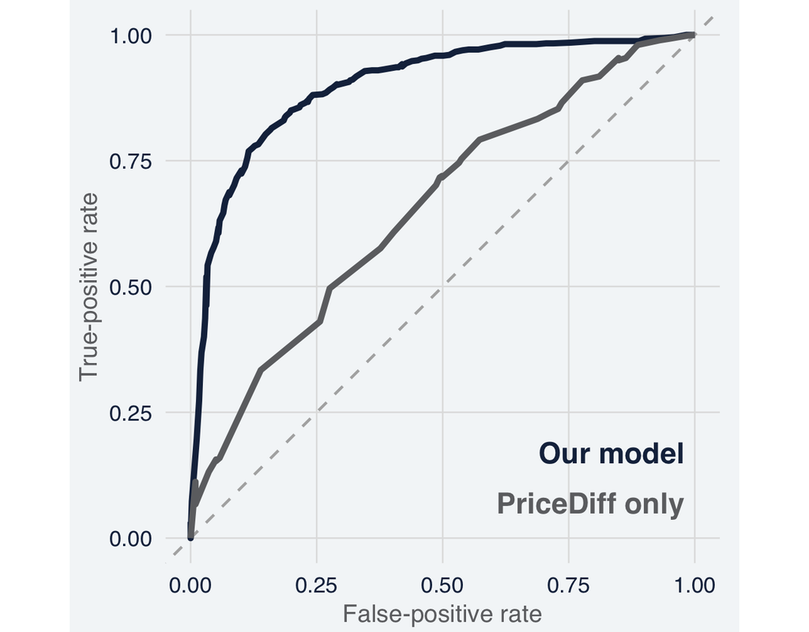

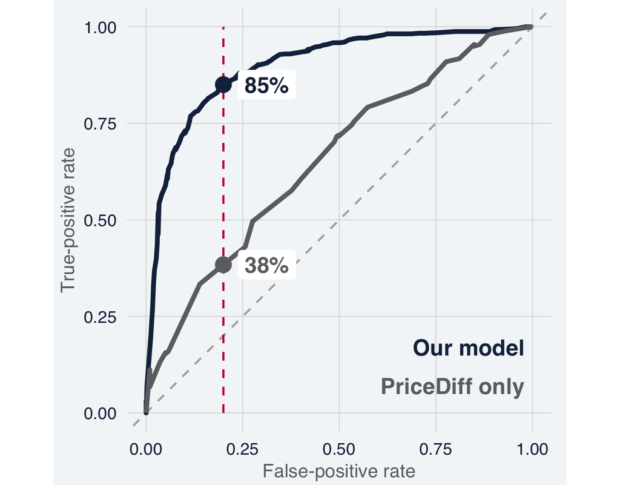

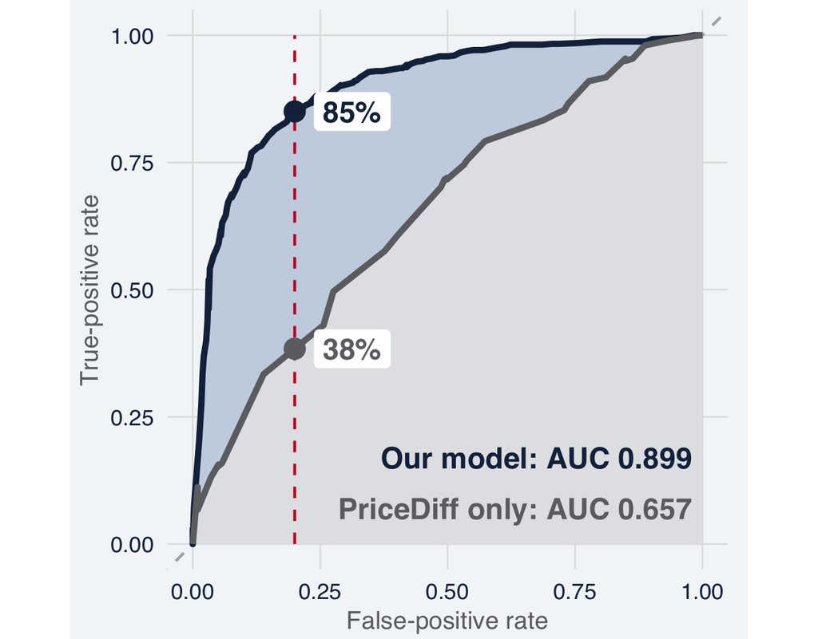

**Same false alarms, more CH buyers found.** At a false-positive rate of 0.20 (red line), our model finds 85% of CH buyers; PriceDiff only finds 38%. A higher curve does better at every level of false alarms.

**The AUC is the area under the curve:** the average share of CH buyers found, over all false-positive rates. One number for how high the curve is: 0.899 against 0.657.

**1. Which model?** The higher curve, the bigger AUC.  
**2. Which threshold?** The cost of each error, as on slide 40.

## What does the AUC number mean?

Pick a random CH buyer and a random MM buyer. Does the CH buyer get the higher probability of CH?

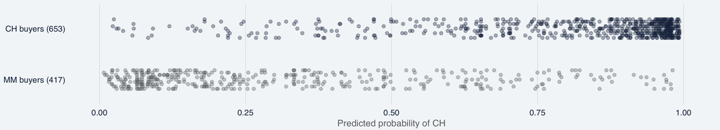

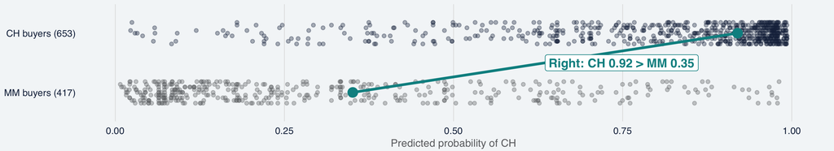

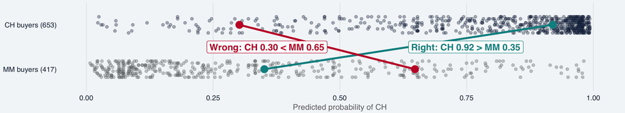

**All 653 × 417 = 272,301 pairs:** the model ranks 89.9% right. That share is the AUC, $P(\hat p_{\text{CH}} > \hat p_{\text{MM}}) = 0.899$, the same as the area on slide 41.

```r
auc_of <- function(p, y) {                        # pairs ranked right
  ch <- p[y == 1]; mm <- p[y == 0]                # CH and MM visits
  mean(outer(ch, mm, ">") + 0.5 * outer(ch, mm, "=="))  # ties count half
}
round(auc_of(oj$p_hat, oj$Y), 3)                  # 272,301 pairs
```

```
[1] 0.899
```

- **0.5, a coin toss:** the two rows would lie on top of each other.
- **1, perfect:** every CH dot to the right of every MM dot.
- **Wrong pairs come from the overlap** in the middle of the plot.
- **Gini** $= 2 \times 0.899 - 1 = 0.80$: the same scale, with a coin toss at 0. Often reported in credit and marketing.

## Who should get the Citrus Hill coupon?

The brand manager has coupons for 10% of the visits and wants the coupons to go to shoppers with a high probability of buying MM. Sort the visits by the probability of MM, $1 - p$, highest first.

```r
o   <- order(1 - oj$p_hat, decreasing = TRUE)       # visits sorted by P(MM), highest first
mm  <- oj$Y[o] == 0                                 # TRUE if that visit bought MM
round(c(top10 = mean(mm[1:107]), all = mean(mm),    # MM share: top 10% (107 visits) vs all visits
        lift = mean(mm[1:107]) / mean(mm),          # lift in the top 10%
        reached_top30 = sum(mm[1:321]) / sum(mm)), 3)   # share of MM buyers in the top 30%
```

```
        top10           all          lift reached_top30
        0.916         0.390         2.350         0.655
```

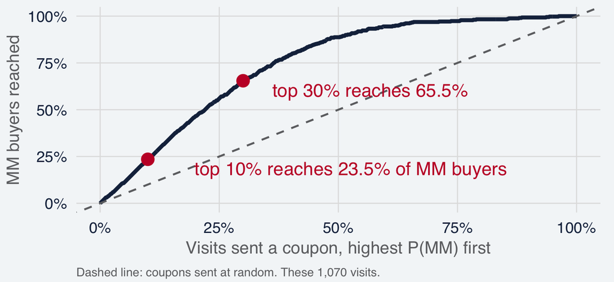

- **Top 10%, 107 visits:** **98** bought MM, a share of **91.6%**, against **39.0%** in all visits.
- **Lift in the top 10%:** $\frac{91.6\%}{39.0\%} \approx 2.35$. Coupons sent at random to 107 visits would reach about 42 MM buyers. The model reaches 98.
- **Top 30%, 321 visits:** reaches **65.5%** of the 417 MM buyers. At random, 30%.
- **HW3 Questions 11–13** draw the same chart for taxi cancellations.

## Do these rates hold for visits the model has not seen?

```r
set.seed(467)                                                   # the same seed as Session 3
test_id <- sample(nrow(oj), floor(0.30 * nrow(oj)))             # 321 visits held out for testing
train <- oj[-test_id, ]; test <- oj[test_id, ]                  # 749 visits to fit, 321 to test
fit_tr <- glm(Y ~ LoyalCH + PriceDiff, data = train, family = binomial)   # fit on training visits only
p_test <- predict(fit_tr, test, type = "response")              # probabilities for the unseen visits
round(c(accuracy = mean((p_test > 0.5) == (test$Y == 1)),       # test accuracy at the 0.5 threshold
        AUC = auc_of(p_test, test$Y)), 3)                       # test AUC
```

```
accuracy      AUC
   0.857    0.903
```

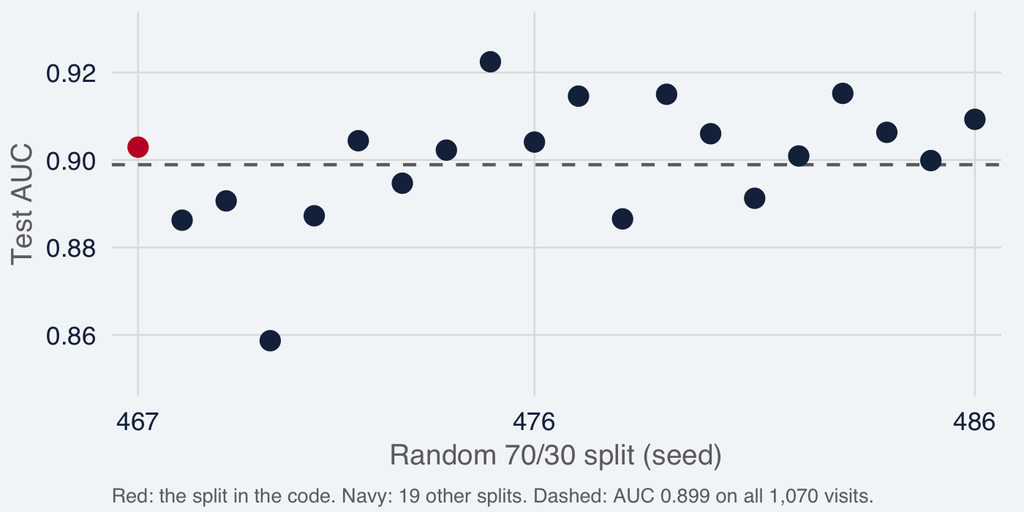

- **This split:** on the 321 test visits, accuracy **0.857** and AUC **0.903**, against 0.831 and 0.899 on all 1,070 visits.
- **One split is one draw:** over 20 random splits, test AUC ranges from **0.86 to 0.92** and averages **0.90**. Test accuracy ranges from **0.80 to 0.86**.
- **Two variables barely overfit:** the test numbers are centered on the in-sample ones. A model with many variables would look better in sample than on the test set (Session 3).
- **Report the test numbers.** HW3 also holds out 30% (seed 46704).

## Summary: metrics for classification models

1. What can we compute from the confusion matrix?
   - At a threshold of 0.5: accuracy 0.831, sensitivity (recall) 0.873, specificity 0.765, precision 0.853, false-positive rate 0.235.
2. What is an ROC curve?
   - The true-positive rate against the false-positive rate, one point for each threshold.
3. Why are ROC curves popular?
   - One picture covers every threshold, and the AUC summarizes it in one number: 0.899 here, 0.5 for random guessing.
4. What is the lift in the top decile?
   - The share of targets in the top 10% of the sorted list over the share in all visits: 91.6% / 39.0% ≈ 2.35 for MM buyers.
5. What does each tool summarize?
   - A confusion matrix: one threshold; report it on a test set. The ROC curve and the AUC: all thresholds. Lift: the top of the sorted list.

## Can we predict which juice a shopper buys?

Yes. The model gives a probability for every visit, and we can now measure its accuracy.

- **The model:** log-odds of CH $= -3.25 + 6.40 \times \text{LoyalCH} + 2.86 \times \text{PriceDiff}$. Loyalty matters most.
- **One visit:** loyalty 0.5 and a gap of +$0.20 give a probability of CH of **0.63**.
- **Accuracy:** at a threshold of 0.5, correct on **83%** of visits, against **61%** for predicting CH for every visit. AUC about **0.90** on these visits and on visits the model has not seen.
- **Still to decide:** which threshold to use. That depends on what each error costs: Wednesday’s lab and HW3 Questions 11–13.